# Zestaw zadań nr 1

Wiktor Kostera

2023-10-10

## Zadanie 1

Celem pierwszego zadania było stworzenie dwóch wektorów i wykonanie na nich podstawowych operacji.

```r
pierwsza <- c(1, 2, 3, 4, 5, 6, 7, 8)
druga <- c(9, 1, 1, 2, 3, 4, 5, 6)
```

Następnie utworzone wektory możemy wywołać.

```r
pierwsza
```

```
## [1] 1 2 3 4 5 6 7 8
```

```r
druga
```

```
## [1] 9 1 1 2 3 4 5 6
```

Kolejnym elementem było policzenie sumy, różnicy oraz dodanie do pierwszego wektora wartości 1.

```r
suma <- pierwsza + druga
suma
```

```
## [1] 10  3  4  6  8 10 12 14
```

```r
roznica <- pierwsza - druga
roznica
```

```
## [1] -8  1  2  2  2  2  2  2
```

```r
wiecej <- pierwsza + 1
wiecej
```

```
## [1] 2 3 4 5 6 7 8 9
```

Następnie należało wyznaczyć średnią oraz odchylenie standardowe.

```r
mean(pierwsza)
```

```
## [1] 4.5
```

```r
sd(pierwsza)
```

```
## [1] 2.44949
```

## Zadanie 2

Drugie zadanie zostało poświęcone wprowadzeniu ramki danych `osoby` dla siedmiu obserwacji o wartościach `waga` oraz `wzrost`.

```r
wzrost <- c(175, 180, 168, 185, 170, 190, 163)
waga <- c(98, 76, 58, 90, 64, 80, 58)
osoby <- data.frame(wzrost, waga)
osoby
```

```
##   wzrost waga
## 1    175   98
## 2    180   76
## 3    168   58
## 4    185   90
## 5    170   64
## 6    190   80
## 7    163   58
```

Następnie z wykorzystaniem kilku funkcji można przeprowadzić podstawową inspekcję wprowadzonych danych.

```r
str(osoby)
```

```
## 'data.frame':    7 obs. of  2 variables:
##  $ wzrost: num  175 180 168 185 170 190 163
##  $ waga  : num  98 76 58 90 64 80 58
```

```r
head(osoby)
```

```
##   wzrost waga
## 1    175   98
## 2    180   76
## 3    168   58
## 4    185   90
## 5    170   64
## 6    190   80
```

```r
tail(osoby)
```

```
##   wzrost waga
## 2    180   76
## 3    168   58
## 4    185   90
## 5    170   64
## 6    190   80
## 7    163   58
```

```r
dim(osoby)
```

```
## [1] 7 2
```

```r
summary(osoby)
```

```
##      wzrost           waga
##  Min.   :163.0   Min.   :58.00
##  1st Qu.:169.0   1st Qu.:61.00
##  Median :175.0   Median :76.00
##  Mean   :175.9   Mean   :74.86
##  3rd Qu.:182.5   3rd Qu.:85.00
##  Max.   :190.0   Max.   :98.00
```

## Zadanie 3

W kolejnym zadaniu dla danych z poprzedniego przykładu należało dodać nazwy wierszy.

```r
rownames(osoby) <- c("Michał", "Jacek", "Ola", "Dawid", "Weronika", "Wiktor", "Ewa")
osoby
```

```
##          wzrost waga
## Michał      175   98
## Jacek       180   76
## Ola         168   58
## Dawid       185   90
## Weronika    170   64
## Wiktor      190   80
## Ewa         163   58
```

Kolejnym elementem było stworzenie obiektu `BMI`, wyświetlenie osób o BMI wyższym niż 30, a także zliczenie osób o BMI ≤ 25.

```r
BMI <- waga/(wzrost/100)^2
osoby <- data.frame(wzrost, waga, BMI)
osoby
```

```
##   wzrost waga      BMI
## 1    175   98 32.00000
## 2    180   76 23.45679
## 3    168   58 20.54989
## 4    185   90 26.29657
## 5    170   64 22.14533
## 6    190   80 22.16066
## 7    163   58 21.82995
```

```r
osoby[osoby$BMI > 30,]
```

```
##   wzrost waga BMI
## 1    175   98  32
```

```r
sum(osoby$BMI <= 25)
```

```
## [1] 5
```

## Zadanie 4

Zadanie 4. zostało poświęcone ramkom danych `mtcars` oraz `Orange`. Pierwsza z nich to ramka danych opisująca zużycie paliwa i 10 aspektów konstrukcyjnych dla 32 samochodów z lat 1973-1974. Z kolei druga opisuje dane dotyczące drzew pomarańczy. Poniższy fragment kodu pokazuje oba zestawy danych.

```r
mtcars
```

```
##                      mpg cyl  disp  hp drat    wt  qsec vs am gear carb
## Mazda RX4           21.0   6 160.0 110 3.90 2.620 16.46  0  1    4    4
## Mazda RX4 Wag       21.0   6 160.0 110 3.90 2.875 17.02  0  1    4    4
## Datsun 710          22.8   4 108.0  93 3.85 2.320 18.61  1  1    4    1
## Hornet 4 Drive      21.4   6 258.0 110 3.08 3.215 19.44  1  0    3    1
## Hornet Sportabout   18.7   8 360.0 175 3.15 3.440 17.02  0  0    3    2
## Valiant             18.1   6 225.0 105 2.76 3.460 20.22  1  0    3    1
## Duster 360          14.3   8 360.0 245 3.21 3.570 15.84  0  0    3    4
## Merc 240D           24.4   4 146.7  62 3.69 3.190 20.00  1  0    4    2
## Merc 230            22.8   4 140.8  95 3.92 3.150 22.90  1  0    4    2
## Merc 280            19.2   6 167.6 123 3.92 3.440 18.30  1  0    4    4
## Merc 280C           17.8   6 167.6 123 3.92 3.440 18.90  1  0    4    4
## Merc 450SE          16.4   8 275.8 180 3.07 4.070 17.40  0  0    3    3
## Merc 450SL          17.3   8 275.8 180 3.07 3.730 17.60  0  0    3    3
## Merc 450SLC         15.2   8 275.8 180 3.07 3.780 18.00  0  0    3    3
## Cadillac Fleetwood  10.4   8 472.0 205 2.93 5.250 17.98  0  0    3    4
## Lincoln Continental 10.4   8 460.0 215 3.00 5.424 17.82  0  0    3    4
## Chrysler Imperial   14.7   8 440.0 230 3.23 5.345 17.42  0  0    3    4
## Fiat 128            32.4   4  78.7  66 4.08 2.200 19.47  1  1    4    1
## Honda Civic         30.4   4  75.7  52 4.93 1.615 18.52  1  1    4    2
## Toyota Corolla      33.9   4  71.1  65 4.22 1.835 19.90  1  1    4    1
## Toyota Corona       21.5   4 120.1  97 3.70 2.465 20.01  1  0    3    1
## Dodge Challenger    15.5   8 318.0 150 2.76 3.520 16.87  0  0    3    2
## AMC Javelin         15.2   8 304.0 150 3.15 3.435 17.30  0  0    3    2
## Camaro Z28          13.3   8 350.0 245 3.73 3.840 15.41  0  0    3    4
## Pontiac Firebird    19.2   8 400.0 175 3.08 3.845 17.05  0  0    3    2
## Fiat X1-9           27.3   4  79.0  66 4.08 1.935 18.90  1  1    4    1
## Porsche 914-2       26.0   4 120.3  91 4.43 2.140 16.70  0  1    5    2
## Lotus Europa        30.4   4  95.1 113 3.77 1.513 16.90  1  1    5    2
## Ford Pantera L      15.8   8 351.0 264 4.22 3.170 14.50  0  1    5    4
## Ferrari Dino        19.7   6 145.0 175 3.62 2.770 15.50  0  1    5    6
## Maserati Bora       15.0   8 301.0 335 3.54 3.570 14.60  0  1    5    8
## Volvo 142E          21.4   4 121.0 109 4.11 2.780 18.60  1  1    4    2
```

```r
Orange
```

```
##    Tree  age circumference
## 1     1  118            30
## 2     1  484            58
## 3     1  664            87
## 4     1 1004           115
## 5     1 1231           120
## 6     1 1372           142
## 7     1 1582           145
## 8     2  118            33
## 9     2  484            69
## 10    2  664           111
## 11    2 1004           156
## 12    2 1231           172
## 13    2 1372           203
## 14    2 1582           203
```

[output cut: 21 more lines]

Przy użyciu funkcji `str()` możemy poznać ich strukturę.

```r
str(mtcars)
```

```
## 'data.frame':    32 obs. of  11 variables:
##  $ mpg : num  21 21 22.8 21.4 18.7 18.1 14.3 24.4 22.8 19.2 ...
##  $ cyl : num  6 6 4 6 8 6 8 4 4 6 ...
##  $ disp: num  160 160 108 258 360 ...
##  $ hp  : num  110 110 93 110 175 105 245 62 95 123 ...
##  $ drat: num  3.9 3.9 3.85 3.08 3.15 2.76 3.21 3.69 3.92 3.92 ...
##  $ wt  : num  2.62 2.88 2.32 3.21 3.44 ...
##  $ qsec: num  16.5 17 18.6 19.4 17 ...
##  $ vs  : num  0 0 1 1 0 1 0 1 1 1 ...
##  $ am  : num  1 1 1 0 0 0 0 0 0 0 ...
##  $ gear: num  4 4 4 3 3 3 3 4 4 4 ...
##  $ carb: num  4 4 1 1 2 1 4 2 2 4 ...
```

```r
str(Orange)
```

```
## Classes 'nfnGroupedData', 'nfGroupedData', 'groupedData' and 'data.frame':   35 obs. of  3 variables:
##  $ Tree         : Ord.factor w/ 5 levels "3"<"1"<"5"<"2"<..: 2 2 2 2 2 2 2 4 4 4 ...
##  $ age          : num  118 484 664 1004 1231 ...
##  $ circumference: num  30 58 87 115 120 142 145 33 69 111 ...
##  - attr(*, "formula")=Class 'formula'  language circumference ~ age | Tree
##   .. ..- attr(*, ".Environment")=<environment: R_EmptyEnv>
##  - attr(*, "labels")=List of 2
##   ..$ x: chr "Time since December 31, 1968"
##   ..$ y: chr "Trunk circumference"
##  - attr(*, "units")=List of 2
##   ..$ x: chr "(days)"
##   ..$ y: chr "(mm)"
```

Dalsza część zadania jest poświęcona poszczególnym operacjom na tych zestawach. Poniższe linie kodu umożliwiają przedstawienie aut posiadających 6 cylindrów oraz policzenie średniej liczby koni mechanicznych dla aut o spalaniu mniejszym niż 20.

```r
mtcars[mtcars$cyl == 6,]
```

```
##                 mpg cyl  disp  hp drat    wt  qsec vs am gear carb
## Mazda RX4      21.0   6 160.0 110 3.90 2.620 16.46  0  1    4    4
## Mazda RX4 Wag  21.0   6 160.0 110 3.90 2.875 17.02  0  1    4    4
## Hornet 4 Drive 21.4   6 258.0 110 3.08 3.215 19.44  1  0    3    1
## Valiant        18.1   6 225.0 105 2.76 3.460 20.22  1  0    3    1
## Merc 280       19.2   6 167.6 123 3.92 3.440 18.30  1  0    4    4
## Merc 280C      17.8   6 167.6 123 3.92 3.440 18.90  1  0    4    4
## Ferrari Dino   19.7   6 145.0 175 3.62 2.770 15.50  0  1    5    6
```

```r
mean(mtcars[mtcars$mpg < 20,]$hp)
```

```
## [1] 191.9444
```

Na sam koniec należało zbudować histogram dla jednej wybranej zmiennej z zestawu `Orange` oraz narysowanie wykresy pudełkowego dla zmiennych `mpg`, `hp` i `qsec` z zestawu `mtcars`. Z uwagi na dużą różnicę w ich wartościach postanowiłem podzielić wykres pudełkowy na dwa osobne: jeden prezentujący dane dla zmiennej `hp` oraz drugi dla danych `mpg` oraz `qsec`.

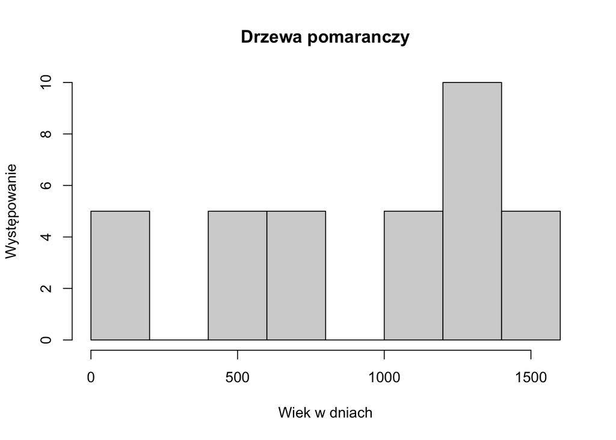

```r
hist(Orange$age, main = "Drzewa pomaranczy",
     xlab = "Wiek w dniach",
     ylab = "Występowanie")
```

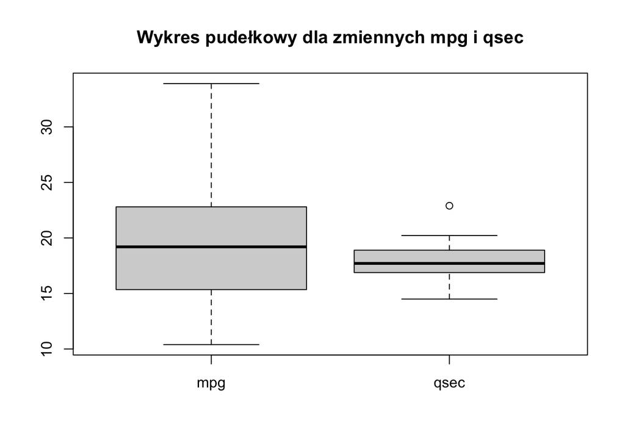

```r
boxplot(data.frame("mpg"= mtcars$mpg, "qsec" = mtcars$qsec),
        main = "Wykres pudełkowy dla zmiennych mpg i qsec")
```

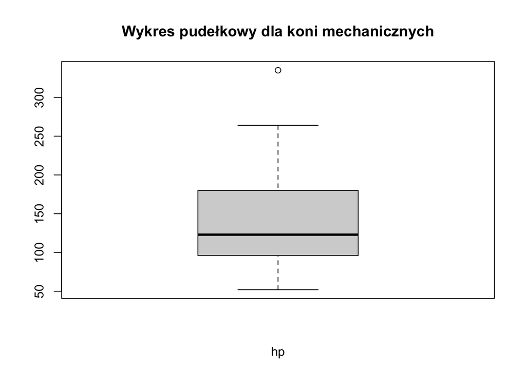

```r
boxplot(mtcars$hp,
        main = "Wykres pudełkowy dla koni mechanicznych",
        xlab = "hp")
```

## Zadanie 5

```r
library("psych")

describe(mtcars)
```

```
##      vars  n   mean     sd median trimmed    mad   min    max  range  skew
## mpg     1 32  20.09   6.03  19.20   19.70   5.41 10.40  33.90  23.50  0.61
## cyl     2 32   6.19   1.79   6.00    6.23   2.97  4.00   8.00   4.00 -0.17
## disp    3 32 230.72 123.94 196.30  222.52 140.48 71.10 472.00 400.90  0.38
## hp      4 32 146.69  68.56 123.00  141.19  77.10 52.00 335.00 283.00  0.73
## drat    5 32   3.60   0.53   3.70    3.58   0.70  2.76   4.93   2.17  0.27
## wt      6 32   3.22   0.98   3.33    3.15   0.77  1.51   5.42   3.91  0.42
## qsec    7 32  17.85   1.79  17.71   17.83   1.42 14.50  22.90   8.40  0.37
## vs      8 32   0.44   0.50   0.00    0.42   0.00  0.00   1.00   1.00  0.24
## am      9 32   0.41   0.50   0.00    0.38   0.00  0.00   1.00   1.00  0.36
## gear   10 32   3.69   0.74   4.00    3.62   1.48  3.00   5.00   2.00  0.53
## carb   11 32   2.81   1.62   2.00    2.65   1.48  1.00   8.00   7.00  1.05
##      kurtosis    se
## mpg     -0.37  1.07
## cyl     -1.76  0.32
## disp    -1.21 21.91
## hp      -0.14 12.12
## drat    -0.71  0.09
## wt      -0.02  0.17
## qsec     0.34  0.32
## vs      -2.00  0.09
## am      -1.92  0.09
## gear    -1.07  0.13
## carb     1.26  0.29
```

```r
summary(mtcars)
```

```
##       mpg             cyl             disp             hp
##  Min.   :10.40   Min.   :4.000   Min.   : 71.1   Min.   : 52.0
##  1st Qu.:15.43   1st Qu.:4.000   1st Qu.:120.8   1st Qu.: 96.5
##  Median :19.20   Median :6.000   Median :196.3   Median :123.0
##  Mean   :20.09   Mean   :6.188   Mean   :230.7   Mean   :146.7
##  3rd Qu.:22.80   3rd Qu.:8.000   3rd Qu.:326.0   3rd Qu.:180.0
##  Max.   :33.90   Max.   :8.000   Max.   :472.0   Max.   :335.0
##       drat             wt             qsec             vs
##  Min.   :2.760   Min.   :1.513   Min.   :14.50   Min.   :0.0000
##  1st Qu.:3.080   1st Qu.:2.581   1st Qu.:16.89   1st Qu.:0.0000
##  Median :3.695   Median :3.325   Median :17.71   Median :0.0000
##  Mean   :3.597   Mean   :3.217   Mean   :17.85   Mean   :0.4375
##  3rd Qu.:3.920   3rd Qu.:3.610   3rd Qu.:18.90   3rd Qu.:1.0000
##  Max.   :4.930   Max.   :5.424   Max.   :22.90   Max.   :1.0000
##        am              gear            carb
##  Min.   :0.0000   Min.   :3.000   Min.   :1.000
##  1st Qu.:0.0000   1st Qu.:3.000   1st Qu.:2.000
##  Median :0.0000   Median :4.000   Median :2.000
##  Mean   :0.4062   Mean   :3.688   Mean   :2.812
##  3rd Qu.:1.0000   3rd Qu.:4.000   3rd Qu.:4.000
##  Max.   :1.0000   Max.   :5.000   Max.   :8.000
```

Jak widać różnica pomiędzy nimi jest taka, że `describe()` pokazuje więcej statystyk dla danych wyświetlanych w wierszach w odróżnieniu do kilku mniej szczegółowych wartości wyświetlanych w grupach przy użyciu funkcji `summary()`.

Następnie zadanie polegało na zapoznaniu się z funkcją `describeBy()`. Jest to funkcja pozwalająca na wyświetlanie statystyk dla poszczególnych zmiennych i ich grupowaniu. W poniższym przykładzie grupuje po ilości cylindrów silnika dzięki czemu możemy porównac jak zachowują się dane statystyczne dla poszczególnych wartości cylindrów: 4, 6, 8.

```r
describeBy(mtcars, "cyl")
```

```
##
##  Descriptive statistics by group
## cyl: 4
##      vars  n   mean    sd median trimmed   mad   min    max range  skew
## mpg     1 11  26.66  4.51  26.00   26.44  6.52 21.40  33.90 12.50  0.26
## cyl     2 11   4.00  0.00   4.00    4.00  0.00  4.00   4.00  0.00   NaN
## disp    3 11 105.14 26.87 108.00  104.30 43.00 71.10 146.70 75.60  0.12
## hp      4 11  82.64 20.93  91.00   82.67 32.62 52.00 113.00 61.00  0.01
## drat    5 11   4.07  0.37   4.08    4.02  0.34  3.69   4.93  1.24  1.00
## wt      6 11   2.29  0.57   2.20    2.27  0.54  1.51   3.19  1.68  0.30
## qsec    7 11  19.14  1.68  18.90   18.99  1.48 16.70  22.90  6.20  0.55
## vs      8 11   0.91  0.30   1.00    1.00  0.00  0.00   1.00  1.00 -2.47
## am      9 11   0.73  0.47   1.00    0.78  0.00  0.00   1.00  1.00 -0.88
## gear   10 11   4.09  0.54   4.00    4.11  0.00  3.00   5.00  2.00  0.11
## carb   11 11   1.55  0.52   2.00    1.56  0.00  1.00   2.00  1.00 -0.16
##      kurtosis   se
## mpg     -1.65 1.36
## cyl       NaN 0.00
## disp    -1.64 8.10
## hp      -1.71 6.31
## drat     0.12 0.11
## wt      -1.36 0.17
## qsec    -0.02 0.51
## vs       4.52 0.09
## am      -1.31 0.14
## gear    -0.01 0.16
## carb    -2.15 0.16
## ------------------------------------------------------------
## cyl: 6
##      vars n   mean    sd median trimmed   mad    min    max  range  skew
## mpg     1 7  19.74  1.45  19.70   19.74  1.93  17.80  21.40   3.60 -0.16
## cyl     2 7   6.00  0.00   6.00    6.00  0.00   6.00   6.00   0.00   NaN
## disp    3 7 183.31 41.56 167.60  183.31 11.27 145.00 258.00 113.00  0.80
## hp      4 7 122.29 24.26 110.00  122.29  7.41 105.00 175.00  70.00  1.36
## drat    5 7   3.59  0.48   3.90    3.59  0.03   2.76   3.92   1.16 -0.74
## wt      6 7   3.12  0.36   3.21    3.12  0.36   2.62   3.46   0.84 -0.22
## qsec    7 7  17.98  1.71  18.30   17.98  1.90  15.50  20.22   4.72 -0.12
## vs      8 7   0.57  0.53   1.00    0.57  0.00   0.00   1.00   1.00 -0.23
## am      9 7   0.43  0.53   0.00    0.43  0.00   0.00   1.00   1.00  0.23
## gear   10 7   3.86  0.69   4.00    3.86  0.00   3.00   5.00   2.00  0.11
```

[output cut: 24 more lines]

```
## am      9 14   0.14  0.36   0.00    0.08  0.00   0.00   1.00   1.00  1.83
## gear   10 14   3.29  0.73   3.00    3.17  0.00   3.00   5.00   2.00  1.83
## carb   11 14   3.50  1.56   3.50    3.25  0.74   2.00   8.00   6.00  1.48
##      kurtosis    se
## mpg     -0.57  0.68
## cyl       NaN  0.00
## disp    -1.26 18.11
## hp       0.09 13.62
## drat     1.08  0.10
## wt      -0.71  0.20
## qsec    -0.92  0.32
## vs        NaN  0.00
## am       1.45  0.10
## gear     1.45  0.19
## carb     2.24  0.42
```

## Zadanie 6

Kolejne zadanie poświęcone jest danym wylosowanym przez poszczególne funkcje. Na początku należało wygenerować 20 wyników rzutu kostką do gry oraz nazwać tę zmienną `proba`. Następnie trzeba było odpowiedzieć na pytanie: ile wynosi średnia i odchylenie standardowe?

```r
proba <- sample(1:6, 20, replace = TRUE)
proba
```

```
##  [1] 2 4 1 3 3 1 6 5 4 2 5 5 6 5 2 3 5 1 5 5
```

```r
mean(proba)
```

```
## [1] 3.65
```

```r
sd(proba)
```

```
## [1] 1.694418
```

Elementem zadania było również wygenerowanie 100 rzutów monetą, przypisanie ich do zmiennej `rzut` oraz udzielenie odpowiedzi na pytanie: ile wypadło orłów?

```r
rzut <- sample(0:1, 100, replace = TRUE)
sum(rzut)
```

```
## [1] 52
```

Należało również wylosować bez zwracania 10 liczb ze zbioru liczb naturalnych od 1 do 100, a także zapoznanie się z trzema funkcjami: `rnorm()`, `rpois()` oraz `rt()` i przestawienie użycia jednej z nich na wybranym przykładzie.

```r
bez_zwracania <- sample(1:100, 10, replace = FALSE)
bez_zwracania
```

```
##  [1]  67  94  25  55  34  66  98  65 100  77
```

```r
x1 <- rnorm(10, mean = 12, sd = 3)
x1
```

```
##  [1] 13.440141 12.809930 11.381684 14.597877  8.859553 10.335771 16.081756
##  [8] 13.927389  9.423961 14.197159
```

## Zadanie 7

W zadaniu siódmym należało stworzyć listę w oparciu o podaną instrukcję.

```r
lista <- list(palenie = c(F,T,T,F,F,T,F),
              cyfry = 0:9,
              macierz = matrix(sample(1:5,16,replace = T),4,4),
              tekst = c("Litwo", "ojczyzno", "moja", "ty",
                         "jestes", "jak", "zdrowie"))
lista
```

```
## $palenie
## [1] FALSE  TRUE  TRUE FALSE FALSE  TRUE FALSE
##
## $cyfry
##  [1] 0 1 2 3 4 5 6 7 8 9
##
## $macierz
##      [,1] [,2] [,3] [,4]
## [1,]    3    4    4    1
## [2,]    4    3    5    2
## [3,]    3    5    4    1
## [4,]    2    5    5    4
##
## $tekst
## [1] "Litwo"    "ojczyzno" "moja"     "ty"       "jestes"   "jak"      "zdrowie"
```

Kolejnym etapem było odwołanie się do:

- obiektu `tekst`,

```r
lista[[4]]
```

```
## [1] "Litwo"    "ojczyzno" "moja"     "ty"       "jestes"   "jak"      "zdrowie"
```

```r
lista[["tekst"]]
```

```
## [1] "Litwo"    "ojczyzno" "moja"     "ty"       "jestes"   "jak"      "zdrowie"
```

- trzeciego elementu wektora `cyfry`,

```r
lista$cyfry[3]
```

```
## [1] 2
```

- trzeciej kolumny obiektu `macierz`.

```r
lista$macierz[, 3]
```

```
## [1] 4 5 4 5
```

## Zadanie 8

Zadanie ósme polegało na zdefiniowaniu zmiennej `wiek` i `waga`. Są to zmienne opisujące osoby o danej wadze i danym wieku. Kolejnym etapem było zbudowanie z nich ramki danych `pacjenci`, a następnie wykluczenie z zestawu osoby o wadze > 90 kg.

```r
wiek <- c(50, 17, 39, 27, 90)
waga <- c(80, 75, 92, 105, 60)

pacjenci <- data.frame(wiek, waga)
pacjenci
```

```
##   wiek waga
## 1   50   80
## 2   17   75
## 3   39   92
## 4   27  105
## 5   90   60
```

```r
pacjenci <- pacjenci[pacjenci$waga <= 90,]
pacjenci
```

```
##   wiek waga
## 1   50   80
## 2   17   75
## 5   90   60
```

## Zadanie 9

W zadaniu dziewiątym należało zainstalować i wczytać zestaw `nycflights13` oraz zgodnie z instrukcją zbudować model regresji.

```r
library(nycflights13)

flight_lm <- lm(arr_delay ~ dep_delay + month + carrier,
                data = flights)
```

Następnie należało odpowiedzieć na poszczególne pytania:

- ile różnych pozycji znajduje się na tej liście,

```r
ile_pozycji <- length(flight_lm)
ile_pozycji
```

```
## [1] 14
```

- jak nazywają się te elementy listy,

```r
nazwy <- names(flight_lm)
nazwy
```

```
##  [1] "coefficients"  "residuals"     "effects"       "rank"
##  [5] "fitted.values" "assign"        "qr"            "df.residual"
##  [9] "na.action"     "contrasts"     "xlevels"       "call"
## [13] "terms"         "model"
```

- wyświetl współczynniki tego modelu.

```r
wspolczynniki <- coefficients(flight_lm)
wspolczynniki
```

```
## (Intercept)   dep_delay       month   carrierAA   carrierAS   carrierB6
## -9.51708354  1.01895142  0.02201799  1.00688211 -6.49669534  5.61792131
##   carrierDL   carrierEV   carrierF9   carrierFL   carrierHA   carrierMQ
##  1.61750225  4.95322249 10.70873197 10.54141321 -2.52973865  9.50579130
##   carrierOO   carrierUA   carrierUS   carrierVX   carrierWN   carrierYV
##  8.43129663  0.68573297  7.68631797 -1.86928468  1.02318926  5.66450384
```

## Zadanie 10

W kolejnym zadaniu należało wczytać macierz `VADeaths`, przedstawiającej dane dotyczące śmierci mężczyzn/kobiet ze wsi/miasta na 1000 osób z podziałem na różne grupy wiekowe. Następnie należało zmienić nazwy etykiet na polskie.

```r
VADeaths
```

```
##       Rural Male Rural Female Urban Male Urban Female
## 50-54       11.7          8.7       15.4          8.4
## 55-59       18.1         11.7       24.3         13.6
## 60-64       26.9         20.3       37.0         19.3
## 65-69       41.0         30.9       54.6         35.1
## 70-74       66.0         54.3       71.1         50.0
```

```r
colnames(VADeaths) <- c("M - wieś", "K - wieś", "M - miasto", "K - miasto")
VADeaths
```

```
##       M - wieś K - wieś M - miasto K - miasto
## 50-54     11.7      8.7       15.4        8.4
## 55-59     18.1     11.7       24.3       13.6
## 60-64     26.9     20.3       37.0       19.3
## 65-69     41.0     30.9       54.6       35.1
## 70-74     66.0     54.3       71.1       50.0
```

```r
wiersze <- rownames(VADeaths)
naglowkiM <- c("M - wieś", "M - miasto")
naglowkiK <- c("K - wieś", "K - miasto")
mezczyzni <- matrix(data = VADeaths[,1:2], nrow = 5, ncol = 2, dimnames = list(wiersze, naglowkiM))
mezczyzni
```

```
##       M - wieś M - miasto
## 50-54     11.7        8.7
## 55-59     18.1       11.7
## 60-64     26.9       20.3
## 65-69     41.0       30.9
## 70-74     66.0       54.3
```

```r
kobiety <- matrix(data = VADeaths[,3:4], nrow = 5, ncol = 2, dimnames = list(wiersze, naglowkiK))
kobiety
```

```
##       K - wieś K - miasto
## 50-54     15.4        8.4
## 55-59     24.3       13.6
## 60-64     37.0       19.3
## 65-69     54.6       35.1
## 70-74     71.1       50.0
```

Następnie należało policzyć średnie dla wierszy i kolumn, a także dodanie ich do nowo utworzonych macierzy.

```r
# dodawanie srednich do macierzy dla mezczyzn
srednie_w_m <- rowMeans(mezczyzni)
mezczyzni <- cbind(mezczyzni, Srednie = srednie_w_m)
srednie_k_m <- colMeans(mezczyzni)
mezczyzni <- rbind(mezczyzni, Srednie = srednie_k_m)
mezczyzni[6, 3] = 0
mezczyzni
```

```
##         M - wieś M - miasto Srednie
## 50-54      11.70       8.70   10.20
## 55-59      18.10      11.70   14.90
## 60-64      26.90      20.30   23.60
## 65-69      41.00      30.90   35.95
## 70-74      66.00      54.30   60.15
## Srednie    32.74      25.18    0.00
```

```r
# dodawanie srednich do macierzy dla kobiet
srednie_w_k <- rowMeans(kobiety)
kobiety <- cbind(kobiety, Srednie = srednie_w_k)
srednie_k_k <- colMeans(kobiety)
kobiety <- rbind(kobiety, Srednie = srednie_k_k)
kobiety[6, 3] = 0
kobiety
```

```
##         K - wieś K - miasto Srednie
## 50-54      15.40       8.40   11.90
## 55-59      24.30      13.60   18.95
## 60-64      37.00      19.30   28.15
## 65-69      54.60      35.10   44.85
## 70-74      71.10      50.00   60.55
## Srednie    40.48      25.28    0.00
```

## Zadanie 11

Zadanie 11. polegało na użyciu instrukcji `if-else` oraz `ifelse` w celu sprawdzenia czy podana liczba jest podzielna przez 4.

```r
liczba <- 120321321

if (liczba %% 4 == 0) {
  "Liczba jest podzielna przez 4"
} else {
  "Liczba nie jest podzielna przez 4"
}
```

```
## [1] "Liczba nie jest podzielna przez 4"
```

```r
ifelse(liczba %% 4 == 0,
       "Liczba jest podzielna przez 4",
       "Liczba nie jest podzielna przez 4")
```

```
## [1] "Liczba nie jest podzielna przez 4"
```

## Zadanie 12

Celem kolejnego zadania było stworzenie zmiennej `ksiazki` zgodnie z podanym schematem. Dane informują ile poszczególna osoba przeczytała książek w minionym kwartale.

```r
ksiazki <- sample(0:4, size = 25, replace = TRUE)
ksiazki
```

```
##  [1] 3 3 1 2 1 3 0 1 4 3 3 2 1 0 2 0 3 3 2 1 1 3 1 4 4
```

Kolejnym etapem zadania było wykonanie odpowiednich poleceń:

- Ile wynosi średnia liczba przeczytanych książek?

```r
mean(ksiazki)
```

```
## [1] 2.04
```

- Ile osób przeczytało przynajmniej trzy książki?

```r
sum(ksiazki >= 3)
```

```
## [1] 11
```

- Ile osób nie przeczytało żadnej książki?

```r
sum(ksiazki == 0)
```

```
## [1] 3
```

- Stworzyć zmienną `ksiazki2`, która będzie mówiła o tym, czy ktoś czyta książki (przeczytał min. jedna). Uzyj do tego petli for.

```r
ksiazki2 <- 0

for(i in 1:25) {
  if (ksiazki[i] != 0)
    ksiazki2 = ksiazki2 + 1
}

ksiazki2
```

```
## [1] 22
```

- Stworzyć instrukcję warunkową, która mając datę (miesiąc i rok), odpowie na pytanie o liczbę dni w tym miesiącu. Zapoznać się z relacją `%in%`.

```r
data <- c(4, 2023)

dni_31 <- c(1, 3, 5, 7, 8, 10, 12)
dni_30 <- c(4, 6, 9, 11)

if (data[1] %in% dni_31) {
  "Liczba dni w podanym miesiacu to 31"
} else if (data[1] %in% dni_30) {
  "Liczba dni w podanym miesiacu to 30"
} else if (data[2] %% 4 == 0) {
  "Liczba dni w podanym miesiacu to 29"
} else {
  "Liczba dni w podanym miesiacu to 28"
}
```

```
## [1] "Liczba dni w podanym miesiacu to 30"
```

## Zadanie 13

Zadanie trzynaste polegało stworzeniu funkcji, która zamienia temperaturę w Celsjuszach na temperaturę w Kelwinach i Fahrenheita.

```r
temperatury <- function(celsjusze) {
  kelwiny <- celsjusze + 273.15
  fahrenheita <- celsjusze * 1.8 + 32
  wyniki <- c(kelwiny, fahrenheita)
  return(wyniki)
}

celsjusze <- 30

wyniki <- temperatury(celsjusze)
```

Następnie możemy wypisać wyniki dla podanej temperatury:

```r
cat("Temperatura w Celsjuszach:", celsjusze, "\n")
```

```
## Temperatura w Celsjuszach: 30
```

```r
cat("Temperatura w Kelwinach:", wyniki[1], "\n")
```

```
## Temperatura w Kelwinach: 303.15
```

```r
cat("Temperatura w Fahrenheitach:", wyniki[2], "\n")
```

```
## Temperatura w Fahrenheitach: 86
```

## Zadanie 14

Kolejnym zadaniem było stworzenie funkcji, która na podstawie długości boków trójkąta, wyznacza jego pole. Należało zadbać o to, by funkcja wyświetliła komunikat, jeśli podane długości boków nie tworzą trójkąta.

```r
pole <- function(boki) {
  boki <- sort(boki, decreasing = T)
  if (boki[3] + boki[2] <= boki[1]) {
    return("Podane wymiary bokow nie tworza trojkata")
  } else {
    p <- (boki[1] + boki[2] + boki[3])/2
    pole <- sqrt(p*(p-boki[1])*(p-boki[2])*(p-boki[3]))
    return(pole)
  }
}

boki <- c(3, 4, 5)
pole_trojkata <- pole(boki)
pole_trojkata
```

```
## [1] 6
```

## Zadanie 15

W zadaniu 15. należało stworzyć funkcję, która na podstawie długości boków trójkąta odpowiada na pytanie o to, czy trójkąt jest ostrokątny, prostokątny lub rozwartokątny.

```r
kat <- function(boki) {
  boki <- sort(boki, decreasing = T)
  if (boki[3]^2 + boki[2]^2 == boki[1]^2) {
    return("Trojkat o podanych bokach jest prostokatny")
  } else if (boki[3]^2 + boki[2]^2 < boki[1]^2) {
    return("Trojkat o podanych bokach jest rozwartokatny")
  } else {
    return("Trojkat o podanych bokach jest ostrokatny")
  }
}

boki <- c(11, 11, 2)
jaki_kat <- kat(boki)
jaki_kat
```

```
## [1] "Trojkat o podanych bokach jest ostrokatny"
```

## Zadanie 16

Kolejne zadanie miało na celu stworzenie ramki danych według podanego schematu.

```r
wzrost <- round(rnorm(100, 175, 10),0)
waga   <- round(wzrost - 105 + rnorm(1,0,5))
wiek   <- sample(20:60, 100, replace = TRUE)
dzieci <- rpois(100, lambda = 1)
osoby  <- data.frame(wzrost = wzrost, waga = waga,
                     wiek = wiek, dzieci = dzieci)
```

Do utworzonej ramki danych należało dołączyć zmienną `BMI` oraz `plec`, gdzie pierwsza połowa danych to kobiety, a druga to mężczyźni.

```r
osoby$BMI <- round(waga/(wzrost/100)^2, 2)

osoby$plec <- rep(c(0,1), each = 50)
osoby
```

```
##     wzrost waga wiek dzieci   BMI plec
## 1      175   67   34      2 21.88    0
## 2      161   53   29      1 20.45    0
## 3      182   74   27      2 22.34    0
## 4      177   69   35      3 22.02    0
## 5      202   94   43      2 23.04    0
## 6      162   54   41      1 20.58    0
## 7      187   79   41      2 22.59    0
## 8      192   84   31      0 22.79    0
## 9      164   56   25      1 20.82    0
## 10     181   73   52      2 22.28    0
## 11     176   68   36      2 21.95    0
## 12     176   68   53      2 21.95    0
## 13     171   63   44      1 21.55    0
## 14     175   67   42      1 21.88    0
```

[output cut: 86 more lines]

Następnie należało wykonać szereg poleceń:

1. Z wykorzystaniem funkcji: `str()`, `head()`, `tail()`, `dim()` oraz `summary()` przyjrzeć się uzyskanemu zestawowi danych.

```r
str(osoby)
```

```
## 'data.frame':    100 obs. of  6 variables:
##  $ wzrost: num  175 161 182 177 202 162 187 192 164 181 ...
##  $ waga  : num  67 53 74 69 94 54 79 84 56 73 ...
##  $ wiek  : int  34 29 27 35 43 41 41 31 25 52 ...
##  $ dzieci: int  2 1 2 3 2 1 2 0 1 2 ...
##  $ BMI   : num  21.9 20.4 22.3 22 23 ...
##  $ plec  : num  0 0 0 0 0 0 0 0 0 0 ...
```

```r
head(osoby)
```

```
##   wzrost waga wiek dzieci   BMI plec
## 1    175   67   34      2 21.88    0
## 2    161   53   29      1 20.45    0
## 3    182   74   27      2 22.34    0
## 4    177   69   35      3 22.02    0
## 5    202   94   43      2 23.04    0
## 6    162   54   41      1 20.58    0
```

```r
tail(osoby)
```

```
##     wzrost waga wiek dzieci   BMI plec
## 95     173   65   55      0 21.72    1
## 96     180   72   26      3 22.22    1
## 97     176   68   48      2 21.95    1
## 98     187   79   46      2 22.59    1
## 99     167   59   49      2 21.16    1
## 100    180   72   54      2 22.22    1
```

```r
dim(osoby)
```

```
## [1] 100   6
```

```r
summary(osoby)
```

```
##      wzrost           waga            wiek           dzieci          BMI
##  Min.   :151.0   Min.   :43.00   Min.   :20.00   Min.   :0.00   Min.   :18.86
##  1st Qu.:169.8   1st Qu.:61.75   1st Qu.:32.00   1st Qu.:0.75   1st Qu.:21.43
##  Median :175.0   Median :67.00   Median :43.00   Median :1.00   Median :21.88
##  Mean   :175.4   Mean   :67.43   Mean   :41.29   Mean   :1.24   Mean   :21.77
##  3rd Qu.:182.0   3rd Qu.:74.00   3rd Qu.:50.00   3rd Qu.:2.00   3rd Qu.:22.34
##  Max.   :202.0   Max.   :94.00   Max.   :60.00   Max.   :4.00   Max.   :23.04
##       plec
##  Min.   :0.0
##  1st Qu.:0.0
##  Median :0.5
##  Mean   :0.5
##  3rd Qu.:1.0
##  Max.   :1.0
```

2. Ile osób w zbiorze danych posiada min. dwójkę dzieci? Spróbuj w tym celu wykorzystać operacje logiczne oraz funkcję `sum()`.

```r
sum(osoby$dzieci >= 2)
```

```
## [1] 38
```

3. Użyj instrukcji logicznych, by wydobyć z danych osoby, które posiadają min. 185 cm wzrostu.

```r
osoby[osoby$wzrost >= 185, ]
```

```
##    wzrost waga wiek dzieci   BMI plec
## 5     202   94   43      2 23.04    0
## 7     187   79   41      2 22.59    0
## 8     192   84   31      0 22.79    0
## 17    191   83   60      1 22.75    0
## 20    188   80   39      1 22.63    0
## 21    187   79   55      0 22.59    0
## 26    189   81   53      1 22.68    0
## 27    186   78   33      1 22.55    0
## 28    192   84   52      2 22.79    0
## 31    185   77   45      2 22.50    0
## 41    185   77   43      2 22.50    0
## 48    186   78   52      0 22.55    0
## 58    199   91   60      1 22.98    1
## 63    185   77   50      2 22.50    1
## 66    189   81   51      2 22.68    1
## 67    186   78   32      0 22.55    1
## 74    185   77   47      1 22.50    1
## 85    185   77   30      0 22.50    1
## 98    187   79   46      2 22.59    1
```

4. Ile wynosi średnia wzrostu w badanej grupie? (użyć np. funkcji `mean()`)? Czy jesteś w stanie odpowiedzieć na pytanie kto jest przecietnie wyższy: kobiety, czy mężczyźni (użyj funkcji `describe.by()` z pakietu `psych` lub podziel zestaw danych na kobiety i mężczyzn i wyznacz odpowiednie statystyki opisowe)

```r
mean(osoby$wzrost)
```

```
## [1] 175.43
```

```r
library("psych")
describeBy(osoby, "plec")
```

```
##
##  Descriptive statistics by group
## plec: 0
##        vars  n   mean    sd median trimmed   mad    min    max range  skew
## wzrost    1 50 176.08  9.67 175.00  175.82 10.38 160.00 202.00 42.00  0.30
## waga      2 50  68.08  9.67  67.00   67.83 10.38  52.00  94.00 42.00  0.30
## wiek      3 50  41.50 10.69  42.00   41.62 14.83  20.00  60.00 40.00 -0.09
## dzieci    4 50   1.22  1.02   1.00    1.12  1.48   0.00   4.00  4.00  0.48
## BMI       5 50  21.82  0.72  21.88   21.87  0.85  20.31  23.04  2.73 -0.46
## plec      6 50   0.00  0.00   0.00    0.00  0.00   0.00   0.00  0.00   NaN
##        kurtosis   se
## wzrost    -0.49 1.37
## waga      -0.49 1.37
## wiek      -1.04 1.51
## dzieci    -0.45 0.14
## BMI       -0.73 0.10
## plec        NaN 0.00
## ------------------------------------------------------------
## plec: 1
##        vars  n   mean    sd median trimmed   mad    min    max range  skew
## wzrost    1 50 174.78  9.02 175.50  175.18  8.15 151.00 199.00 48.00 -0.24
## waga      2 50  66.78  9.02  67.50   67.17  8.15  43.00  91.00 48.00 -0.24
## wiek      3 50  41.08 10.71  44.00   41.42 11.12  21.00  60.00 39.00 -0.26
## dzieci    4 50   1.26  0.94   1.00    1.20  1.48   0.00   4.00  4.00  0.48
## BMI       5 50  21.73  0.80  21.91   21.84  0.59  18.86  22.98  4.12 -1.44
## plec      6 50   1.00  0.00   1.00    1.00  0.00   1.00   1.00  0.00   NaN
##        kurtosis   se
## wzrost     0.41 1.27
## waga       0.41 1.27
## wiek      -1.08 1.51
## dzieci    -0.07 0.13
## BMI        2.33 0.11
## plec        NaN 0.00
```

Odpowiedź na pytanie dotyczące przeciętnego wzrostu można znaleźć w wyświetlonych statystykach patrząc na odpowiednią rubrykę.

5. Z wykorzystaniem instrukcji logicznych pokaż te osoby, które mają BMI > 30. Ile wśród nich to mężczyźni, a ile to kobiety?

Z uwagi na losujące się dane dotyczące wzrostu oraz wagi, za każdym razem zestaw danych wygląda inaczej, dlatego niekiedy wszystkie wartości są wyświetlane za pomocą poniższego kodu, czasami żadne. Instrukcja zgodnie z którą miał zostać utworzony zestaw danych powoduje, że `BMI` nigdy nie osiąga szukanej wartości 30, z tego powodu zdecydowałem się zmienić wartość na 23.5.

```r
osoby[osoby$BMI > 23.5, ]
```

```
## [1] wzrost waga   wiek   dzieci BMI    plec
## <0 rows> (or 0-length row.names)
```

```r
sum(osoby$BMI > 23.5 & osoby$plec == 1)
```

```
## [1] 0
```

```r
sum(osoby$BMI > 23.5 & osoby$plec == 0)
```

```
## [1] 0
```

6. Dołącz do zestawu danych zmienną `wzrost2`, która będzie przyjmowała trzy wartości: niski o ile wzrost < 165, sredni, o ile wzrost jest między 165 i 185 oraz wysoki, gdy wzrost >= 185.

```r
osoby$wzrost2 <- ifelse(osoby$wzrost < 165, "niski", ifelse(osoby$wzrost >= 185, "wysoki", "sredni"))
osoby
```

```
##     wzrost waga wiek dzieci   BMI plec wzrost2
## 1      175   67   34      2 21.88    0  sredni
## 2      161   53   29      1 20.45    0   niski
## 3      182   74   27      2 22.34    0  sredni
## 4      177   69   35      3 22.02    0  sredni
## 5      202   94   43      2 23.04    0  wysoki
## 6      162   54   41      1 20.58    0   niski
## 7      187   79   41      2 22.59    0  wysoki
## 8      192   84   31      0 22.79    0  wysoki
## 9      164   56   25      1 20.82    0   niski
## 10     181   73   52      2 22.28    0  sredni
## 11     176   68   36      2 21.95    0  sredni
## 12     176   68   53      2 21.95    0  sredni
## 13     171   63   44      1 21.55    0  sredni
## 14     175   67   42      1 21.88    0  sredni
```

[output cut: 86 more lines]

7. Skorzystaj z funkcji `summary()` dla zmiennej `wzrost2`. Czy na jej podstawie możesz ocenić, ile osób jest wysokich? Zmień typ tej zmiennej na `factor` - czy to pomogło?

```r
summary(osoby$wzrost2)
```

```
##    Length     Class      Mode
##       100 character character
```

```r
osoby$wzrost2 <- factor(osoby$wzrost2, levels = c("niski", "sredni", "wysoki"))
summary(osoby$wzrost2)
```

```
##  niski sredni wysoki
##     12     69     19
```

## Zadanie 17

Zadanie 17. polegało na stworzeniu listy zgodnie z podaną instrukcją.

```r
lista <- list(palenie = c(F,T,T,F,F,T,F),
              cyfry = 0:9,
              macierz = matrix(sample(1:5, 16, replace = T), 4, 4),
              tekst = c("Litwo", "ojczyzno", "moja", "ty",
                         "jestes", "jak", "zdrowie"))
lista
```

```
## $palenie
## [1] FALSE  TRUE  TRUE FALSE FALSE  TRUE FALSE
##
## $cyfry
##  [1] 0 1 2 3 4 5 6 7 8 9
##
## $macierz
##      [,1] [,2] [,3] [,4]
## [1,]    1    3    4    3
## [2,]    3    4    5    2
## [3,]    2    5    2    4
## [4,]    5    4    3    3
##
## $tekst
## [1] "Litwo"    "ojczyzno" "moja"     "ty"       "jestes"   "jak"      "zdrowie"
```

Kolejnym etapem było odwołanie się do:

- obiektu `tekst`,

```r
lista[[4]]
```

```
## [1] "Litwo"    "ojczyzno" "moja"     "ty"       "jestes"   "jak"      "zdrowie"
```

```r
lista[["tekst"]]
```

```
## [1] "Litwo"    "ojczyzno" "moja"     "ty"       "jestes"   "jak"      "zdrowie"
```

- trzeciego elementu wektora `cyfry`,

```r
lista$cyfry[3]
```

```
## [1] 2
```

- trzeciej kolumny obiektu `macierz`.

```r
lista$macierz[, 3]
```

```
## [1] 4 5 2 3
```

Ostatnim elementem zadania było stworzenie instrukcji warunkowej sprawdzającej czy podana liczba jest podzielna przez 5.

```r
liczba <- 120321320

if (liczba %% 5 == 0) {
  "Liczba jest podzielna przez 5"
} else {
  "Liczba nie jest podzielna przez 5"
}
```

```
## [1] "Liczba jest podzielna przez 5"
```

```r
ifelse(liczba %% 5 == 0,
       "Liczba jest podzielna przez 5",
       "Liczba nie jest podzielna przez 5")
```

```
## [1] "Liczba jest podzielna przez 5"
```

## Zadanie 18

Celem kolejnego zadania było stworzenie zmiennej `ksiazki` zgodnie z podanym schematem. Dane informują ile poszczególna osoba przeczytała książek w minionym kwartale.

```r
ksiazki <- sample(0:4, size = 25, replace = TRUE)
ksiazki
```

```
##  [1] 0 4 3 1 2 1 3 3 2 0 2 3 4 0 1 1 4 3 2 3 2 1 2 3 0
```

Kolejnym etapem zadania było wykonanie odpowiednich poleceń:

- Ile wynosi średnia liczba przeczytanych książek?

```r
mean(ksiazki)
```

```
## [1] 2
```

- Ile osób przeczytało przynajmniej trzy książki?

```r
sum(ksiazki >= 3)
```

```
## [1] 10
```

- Ile osób nie przeczytało żadnej książki?

```r
sum(ksiazki == 0)
```

```
## [1] 4
```

- Stworzyć zmienną `ksiazki2`, która będzie mówiła o tym, czy ktoś czyta książki (przeczytał min. jedna). Uzyj do tego petli for.

```r
ksiazki2 <- 0

for(i in 1:25) {
  if (ksiazki[i] != 0)
    ksiazki2 = ksiazki2 + 1
}

ksiazki2
```

```
## [1] 21
```

## Zadanie 19

Zadanie 19. polegało na stworzeniu funkcji, która mając datę (miesiąc i rok) odpowie na pytanie o liczbę dni w tym miesiącu.

```r
ile_dni <- function(data) {
  dni_31 <- c(1, 3, 5, 7, 8, 10, 12)
  dni_30 <- c(4, 6, 9, 11)

  if (data[1] %in% dni_31) {
    return("Liczba dni w podanym miesiacu to 31")
  } else if (data[1] %in% dni_30) {
    return("Liczba dni w podanym miesiacu to 30")
  } else if (data[2] %% 4 == 0) {
    return("Liczba dni w podanym miesiacu to 29")
  } else {
    return("Liczba dni w podanym miesiacu to 28")
  }
}

data <- c(2, 2024)
ile_dni(data)
```

```
## [1] "Liczba dni w podanym miesiacu to 29"
```

## Zadanie 20

Ostatnim zadaniem w tym zestawie było stworzenie funkcji, która na podstawie określonych wzorów pozwala na policzenie pewnym wartości. Zdecydowałem się na napisanie funkcji, która pozwoli obliczyć pierwiastki równania kwadratowego.

```r
rownanie <- function(wsp) {
  delta <- wsp[2]^2 - 4 * wsp[1] * wsp[3]
  if (delta > 0) {
    x1 <- (-wsp[2] + sqrt(delta))/(2 * wsp[1])
    x2 <- (-wsp[2] - sqrt(delta))/(2 * wsp[1])
    return(cat("Rozwiazaniem rownania kwadratowego o zadanych wspolczynnikach jest x1 =",
               x1, " oraz x2 =", x2))
  }
  else if (delta == 0) {
    x <- -wsp[2]/(2 * wsp[1])
    return(cat("Rozwiazaniem rownania kwadratowego o zadanych wspolczynnikach jest x =", x))
  }
  else {
    re <- -wsp[2]/(2 * wsp[1])
    im <- sqrt(-delta)/(2 * wsp[1])
    return(cat("Rozwiazaniem rownania kwadratowego o zadanych wspolczynnikach jest x1 =",
               re, "+", im,"i  oraz x2 =", re, "-", im,"i"))
  }
}

wsp <- c(1,3,5)
rownanie(wsp)
```

```
## Rozwiazaniem rownania kwadratowego o zadanych wspolczynnikach jest x1 = -1.5 + 1.658312 i  oraz x2 = -1.5 - 1.658312 i
```